# Estudo Proagro

Vitor Villarino

03/09/2019

## Considerações

### Produto

Por enquanto apenas **SOJA**. No futuro teremos Milho.

### Severidade e Intensidade

A Severidade é o valor deferido dividido pelo valor enquadrado das operações deferidas, porém, como a base é agregada e não abre os seguros um a um, não temos os valores enquadrados das operações deferidas. Uma saída é pedir para que eles calculem e nos envie o agregado.

### SAFRA

Ainda há poucos seguros para a safra 2019/2020. Com a nossa regra de 30 seguros por safra (mínimo), vários municípios estavam ficando de fora. Retirei das análises essa safra para não atrapalhar

|  | 2013/2014 | 2014/2015 | 2015/2016 | 2016/2017 | 2017/2018 | 2018/2019 | 2019/2020 | Total |
| --- | --- | --- | --- | --- | --- | --- | --- | --- |
| PRONAF | 105211 | 110330 | 110868 | 101379 | 99977 | 88130 | 20062 | 635957 |
| PRONAMP | 9940 | 9181 | 7272 | 7686 | 7782 | 8160 | 1853 | 51874 |
| SEM PROGRAMA | 2563 | 2563 | 2250 | 2710 | 2375 | 1537 | 195 | 14193 |
| Total | 117714 | 122074 | 120390 | 111775 | 110134 | 97827 | 22110 | 702024 |

### Programas

A distribuição do número de Seguros por Programa mostra que há poucos seguros dos programas PRONAMP e SEM PROGRAMA no Proagro Mais e poucos seguros do PRONAF no PROAGRO TRADICIONAL. Retiraremos estes seguros “outliers”.

| **PROGRAMA** | TP_SEGURO PROAGRO MAIS | TP_SEGURO PROAGRO MAIS | TP_SEGURO PROAGRO MAIS | TP_SEGURO PROAGRO MAIS | TP_SEGURO PROAGRO <br/>TRADICIONAL | TP_SEGURO PROAGRO <br/>TRADICIONAL | TP_SEGURO PROAGRO <br/>TRADICIONAL | TP_SEGURO PROAGRO <br/>TRADICIONAL | Total | Total | Total | Total |
| --- | --- | --- | --- | --- | --- | --- | --- | --- | --- | --- | --- | --- |
| **PRONAF** | 615436.0 | ( | 99.9% | ) | 459.0 | ( | 0.1% | ) | 615895.0 | ( | 100.0% | ) |
| **PRONAMP** | 11.0 | ( | 0.0% | ) | 50010.0 | ( | 100.0% | ) | 50021.0 | ( | 100.0% | ) |
| **SEM PROGRAMA** | 7.0 | ( | 0.1% | ) | 13991.0 | ( | 99.9% | ) | 13998.0 | ( | 100.0% | ) |
| **Total** | 615454.0 | ( | 90.5% | ) | 64460.0 | ( | 9.5% | ) | 679914.0 | ( | 100.0% | ) |

### Inflação

Usei os valores do IPCA acumulado de 12 meses (julho a julho). Peguei do site do IBGE https://ww2.ibge.gov.br/home/estatistica/indicadores/precos/inpc_ipca/defaultseriesHist.shtm e no final obtive os seguintes valores:

| jul2014 | jul2015 | jul2016 | jul2017 | jul2018 | jul2019 |
| --- | --- | --- | --- | --- | --- |
| 6.5 | 9.56 | 8.74 | 2.71 | 4.48 | 3.22 |

Se compararmos os valores deflacionados antes e depois temos uma boa melhora, porém, como o valor máximo do Proagro não foi atualizado, perdemos aquele máximo de R$ 300.000.

Valores antes de deflacionar:

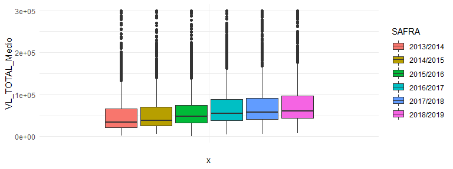

|  | 2013/2014 | 2014/2015 | 2015/2016 | 2016/2017 | 2017/2018 | 2018/2019 |
| --- | --- | --- | --- | --- | --- | --- |
| **Média** | 55466.00 | 59401.32 | 64589.79 | 73880.28 | 76844.58 | 80415.94 |
| **Desv.padrão** | 55812.65 | 55665.95 | 52701.00 | 54178.15 | 56168.03 | 56792.14 |
| **Mín** | 2453.88 | 5490.65 | 118.43 | 4016.00 | 6336.00 | 6998.99 |
| **Med** | 34182.07 | 38233.50 | 47384.26 | 55355.14 | 57395.39 | 60315.70 |
| **Máx** | 300000.00 | 300000.00 | 300000.00 | 300000.00 | 300000.00 | 300000.00 |

Valores depois de deflacionar:

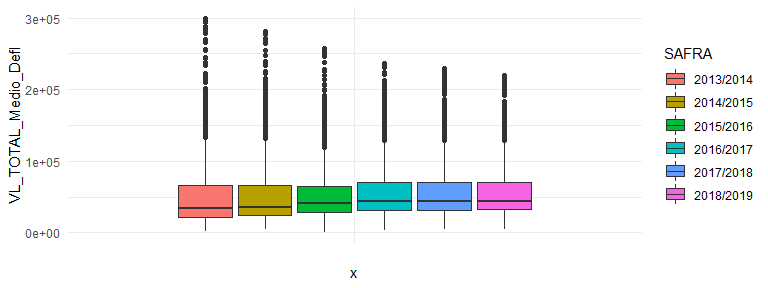

|  | 2013/2014 | 2014/2015 | 2015/2016 | 2016/2017 | 2017/2018 | 2018/2019 |
| --- | --- | --- | --- | --- | --- | --- |
| **Média** | 55466.00 | 55775.88 | 55355.68 | 58228.76 | 58967.07 | 59061.61 |
| **Desv.padrão** | 55812.65 | 52268.50 | 45166.58 | 42700.52 | 43100.82 | 41711.07 |
| **Mín** | 2453.88 | 5155.54 | 101.50 | 3165.21 | 4861.96 | 5140.42 |
| **Med** | 34182.07 | 35900.00 | 40609.95 | 43628.17 | 44042.64 | 44298.96 |
| **Máx** | 300000.00 | 281690.14 | 257110.39 | 236445.09 | 230206.49 | 220335.46 |

### Municípios

Dos 1836 municípios que fizeram alguma operação em alguma safra, sobraram 557 que fizeram pelo menos 30 seguros em todas as safras. Na distribuição por estados, está bem concentrado nos estados do sul do país.

Distribuição por Estado

**Grupo**: "Sigla_UF" = Sigla_UF

| Sigla_UF | Freq | % | % Acum. |
| --- | --- | --- | --- |
| GO | 1 | 0.18 | 0.18 |
| MS | 8 | 1.44 | 1.62 |
| MT | 2 | 0.36 | 1.97 |
| PR | 213 | 38.24 | 40.22 |
| RS | 279 | 50.09 | 90.31 |
| SC | 52 | 9.34 | 99.64 |
| SP | 2 | 0.36 | 100.00 |
| Total | 557 | 100.00 | 100.00 |

Distribuição do número de seguros nesses estados

Distribuição dos Seguros por Estado

|  | 2013/2014 | 2014/2015 | 2015/2016 | 2016/2017 | 2017/2018 | 2018/2019 | Total |
| --- | --- | --- | --- | --- | --- | --- | --- |
| GO | 117 | 96 | 77 | 54 | 50 | 51 | 445 |
| MS | 1149 | 1185 | 1179 | 1028 | 1000 | 834 | 6375 |
| MT | 199 | 185 | 158 | 147 | 127 | 87 | 903 |
| PR | 37893 | 39841 | 39864 | 38155 | 37746 | 32641 | 226140 |
| RS | 64886 | 66096 | 64212 | 59378 | 58408 | 52767 | 365747 |
| SC | 4859 | 5393 | 5670 | 4567 | 4491 | 3926 | 28906 |
| SP | 211 | 201 | 178 | 168 | 135 | 99 | 992 |
| Total | 109314 | 112997 | 111338 | 103497 | 101957 | 90405 | 629508 |

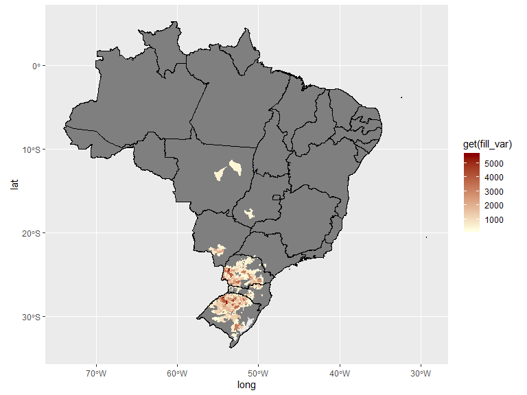

## Análise

### Valor Enquadrado Médio por Área

O Valor Enquadrado (Valor Financiado + Garantia Renda Mínima) por Área dos contratos do Proagro é de 1656.69, porém temos 2 municípios com valores muito baixos: Aratiba(RS) e Constantina(RS).

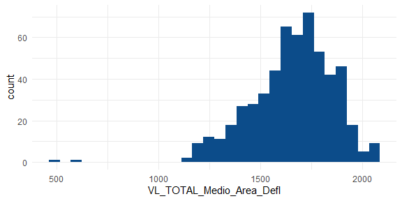

|  | VL_TOTAL_ Medio_Area_ Defl |
| --- | --- |
| **Média** | 1656.69 |
| **Desv.padrão** | 202.06 |
| **Mín** | 503.13 |
| **Q1** | 1543.42 |
| **Med** | 1680.92 |
| **Q3** | 1795.94 |
| **Máx** | 2074.98 |
| **MDA** | 183.14 |
| **IQE** | 252.52 |

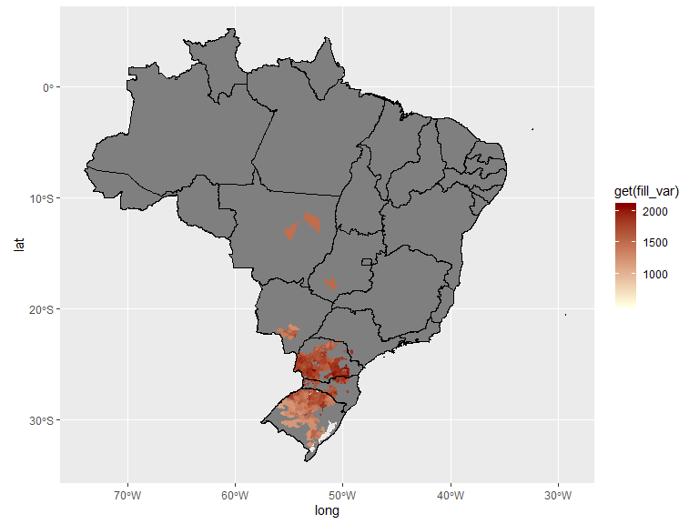

Para estes dois municípios acredito que tenha havido algum tipo de erro. Em uma das safras Constantina teve uma área total mais de 10x maior que a dos outros anos e em Aratiba 15x. A área muito grande interfere na média geral e joga lá para baixo o preço por área. Acredito que seja melhor tirar estes dois municípios.

Seguros Constantina

| SAFRA | PROGRAMA | TP_SEGURO | num_seguros | NR_AREA_TOTAL | VL_TOTAL_deflacionado | VL_TOTAL_Medio_Area_Defl |
| --- | --- | --- | --- | --- | --- | --- |
| 2013/2014 | PRONAF | PROAGRO MAIS | 618 | 6725.77 | 9670289.1 | 1437.7966 |
| 2013/2014 | PRONAMP | PROAGRO TRADICIONAL | 1 | 95.00 | 104500.0 | 1100.0000 |
| 2014/2015 | PRONAF | PROAGRO MAIS | 620 | 96217.77 | 10451162.2 | 108.6199 |
| 2014/2015 | PRONAMP | PROAGRO TRADICIONAL | 5 | 309.21 | 341452.1 | 1104.2725 |
| 2015/2016 | PRONAF | PROAGRO MAIS | 574 | 7475.83 | 14417748.9 | 1928.5817 |
| 2015/2016 | PRONAMP | PROAGRO TRADICIONAL | 6 | 314.40 | 357887.4 | 1138.3186 |
| 2016/2017 | PRONAF | PROAGRO MAIS | 521 | 6801.77 | 13115553.3 | 1928.2559 |
| 2016/2017 | PRONAMP | PROAGRO TRADICIONAL | 3 | 136.00 | 170409.7 | 1253.0126 |
| 2017/2018 | PRONAF | PROAGRO MAIS | 525 | 7293.02 | 14830071.5 | 2033.4610 |
| 2017/2018 | PRONAMP | PROAGRO TRADICIONAL | 9 | 413.73 | 538775.7 | 1302.2399 |
| 2018/2019 | PRONAF | PROAGRO MAIS | 459 | 6285.99 | 12456532.5 | 1981.6342 |
| 2018/2019 | PRONAMP | PROAGRO TRADICIONAL | 8 | 396.95 | 545516.7 | 1374.2706 |

Seguros Aratiba

| SAFRA | PROGRAMA | TP_SEGURO | num_seguros | NR_AREA_TOTAL | VL_TOTAL_deflacionado | VL_TOTAL_Medio_Area_Defl |
| --- | --- | --- | --- | --- | --- | --- |
| 2013/2014 | PRONAF | PROAGRO MAIS | 66 | 15863.37 | 939435.110 | 59.2204 |
| 2013/2014 | PRONAMP | PROAGRO TRADICIONAL | 3 | 64.00 | 66042.290 | 1031.9108 |
| 2014/2015 | PRONAF | PROAGRO MAIS | 83 | 748.84 | 1124541.568 | 1501.7114 |
| 2014/2015 | PRONAMP | PROAGRO TRADICIONAL | 3 | 51.00 | 62700.000 | 1229.4118 |
| 2014/2015 | SEM PROGRAMA | PROAGRO TRADICIONAL | 1 | 4.00 | 4541.634 | 1135.4085 |
| 2015/2016 | PRONAF | PROAGRO MAIS | 101 | 1020.89 | 2155697.386 | 2111.5863 |
| 2015/2016 | PRONAMP | PROAGRO TRADICIONAL | 4 | 60.00 | 74950.909 | 1249.1818 |
| 2016/2017 | PRONAF | PROAGRO MAIS | 60 | 754.50 | 1475844.190 | 1956.0559 |
| 2016/2017 | PRONAMP | PROAGRO TRADICIONAL | 1 | 25.00 | 35466.763 | 1418.6705 |
| 2016/2017 | SEM PROGRAMA | PROAGRO TRADICIONAL | 1 | 38.00 | 53864.910 | 1417.4976 |
| 2017/2018 | PRONAF | PROAGRO MAIS | 95 | 1089.04 | 2206886.729 | 2026.4515 |
| 2017/2018 | PRONAMP | PROAGRO TRADICIONAL | 3 | 57.00 | 83195.291 | 1459.5665 |
| 2018/2019 | PRONAF | PROAGRO MAIS | 86 | 993.50 | 2085195.004 | 2098.8374 |
| 2018/2019 | PRONAMP | PROAGRO TRADICIONAL | 2 | 95.00 | 129065.897 | 1358.5884 |

### Prêmio Médio por Área

Ficou uma gaussiana muito boa. Média de 48 R$/hect.

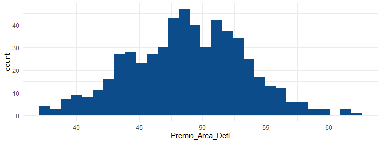

|  | Premio_Area_ Defl |
| --- | --- |
| **Média** | 48.84 |
| **Desv.padrão** | 4.59 |
| **Mín** | 37.31 |
| **Q1** | 45.62 |
| **Med** | 48.94 |
| **Q3** | 52.14 |
| **Máx** | 62.01 |
| **MDA** | 4.75 |
| **IQE** | 6.48 |

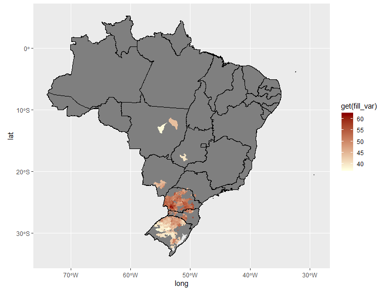

### Índice de Incidência Global (Qtd Sinistros/Qtd Total de Seguros)

O índice de incidência é bem baixo, com média de 3,96% e mediana de 1%. O gráfico de pizza mostra que cerca de 10% dos municípios não tiveram nenhum sinistros entre 2013 - 2018.

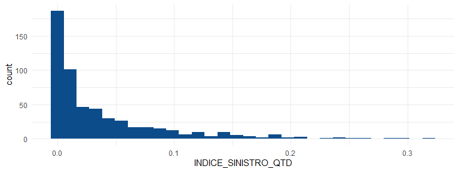

|  | INDICE_ SINISTRO_QTD |
| --- | --- |
| **Média** | 0.04 |
| **Desv.padrão** | 0.05 |
| **Mín** | 0.00 |
| **Q1** | 0.00 |
| **Med** | 0.01 |
| **Q3** | 0.05 |
| **Máx** | 0.32 |
| **MDA** | 0.02 |
| **IQE** | 0.05 |

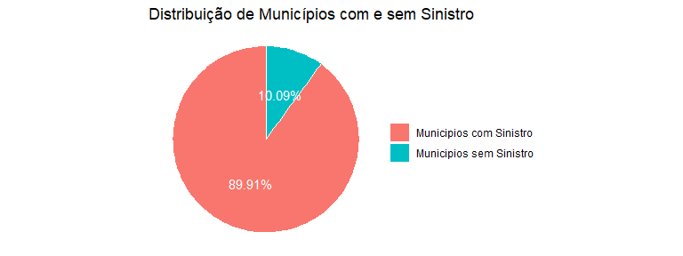

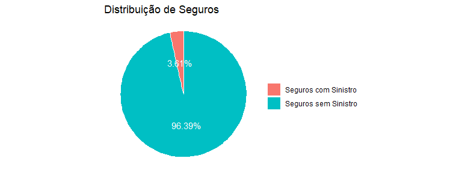

Se retirarmos os municipios que não tiveram 0, temos algo bem parecido.

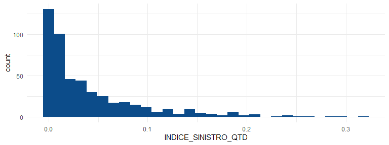

|  | INDICE_ SINISTRO_QTD |
| --- | --- |
| **Média** | 0.04 |
| **Desv.padrão** | 0.05 |
| **Mín** | 0.00 |
| **Q1** | 0.01 |
| **Med** | 0.02 |
| **Q3** | 0.06 |
| **Máx** | 0.32 |
| **MDA** | 0.02 |
| **IQE** | 0.05 |

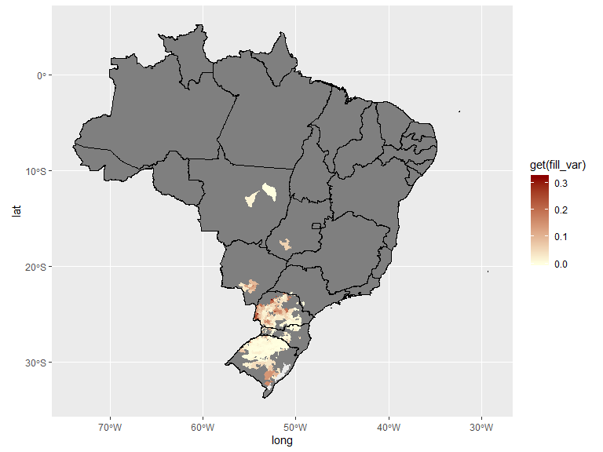

### Sinistro Médio

O sinistro médio tem média de R$16.759 e desvio padrão de aproximadamente R$ 10.000. O municipio de maior média é Piratini-RS. Apesar do valor, não parece ter nada de errado com ele.

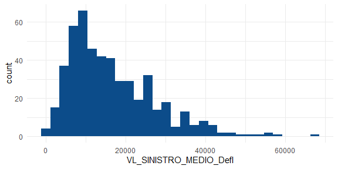

|  | VL_SINISTRO_ MEDIO_Defl |
| --- | --- |
| **Média** | 16759.24 |
| **Desv.padrão** | 10957.01 |
| **Mín** | 774.66 |
| **Q1** | 8583.86 |
| **Med** | 14128.28 |
| **Q3** | 23189.90 |
| **Máx** | 68273.37 |
| **MDA** | 9681.10 |
| **IQE** | 14535.57 |

Seguros Piratini

| SAFRA | PROGRAMA | num_seguros | NR_AREA_TOTAL | QT_SINISTROS | VL_SINISTRO_MEDIO_Defl |
| --- | --- | --- | --- | --- | --- |
| 2013/2014 | PRONAF | 47 | 1889.33 | 1 | 2631.20 |
| 2013/2014 | PRONAMP | 53 | 5598.92 | 0 | NaN |
| 2013/2014 | SEM PROGRAMA | 4 | 480.00 | 0 | NaN |
| 2014/2015 | PRONAF | 50 | 1991.23 | 1 | 15586.28 |
| 2014/2015 | PRONAMP | 44 | 5070.70 | 4 | 68582.05 |
| 2014/2015 | SEM PROGRAMA | 7 | 843.00 | 0 | NaN |
| 2015/2016 | PRONAF | 49 | 2149.40 | 15 | 49267.17 |
| 2015/2016 | PRONAMP | 49 | 5122.65 | 8 | 82460.25 |
| 2015/2016 | SEM PROGRAMA | 10 | 935.70 | 4 | 66448.44 |
| 2016/2017 | PRONAF | 42 | 1775.15 | 0 | NaN |
| 2016/2017 | PRONAMP | 41 | 4064.24 | 0 | NaN |
| 2016/2017 | SEM PROGRAMA | 10 | 1310.00 | 0 | NaN |
| 2017/2018 | PRONAF | 54 | 2252.56 | 18 | 47896.33 |
| 2017/2018 | PRONAMP | 44 | 4841.95 | 23 | 94525.50 |
| 2017/2018 | SEM PROGRAMA | 8 | 909.00 | 5 | 107568.83 |
| 2018/2019 | PRONAF | 52 | 1857.65 | 5 | 36454.64 |
| 2018/2019 | PRONAMP | 41 | 4483.30 | 2 | 79071.37 |
| 2018/2019 | SEM PROGRAMA | 5 | 702.30 | 0 | NaN |

### Índice de Sinistralidade

O índice de sinistralidade também é bem baixo, com média de 2% e mediana de 1%.

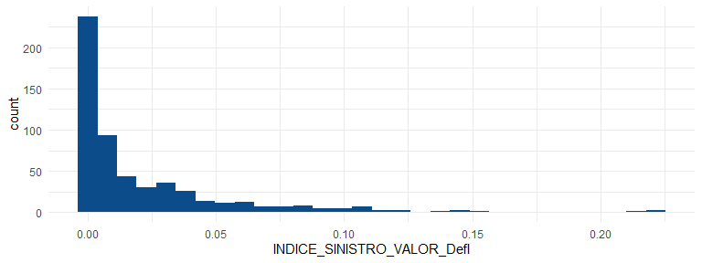

|  | INDICE_ SINISTRO_ VALOR_Defl |
| --- | --- |
| **Média** | 0.02 |
| **Desv.padrão** | 0.03 |
| **Mín** | 0.00 |
| **Q1** | 0.00 |
| **Med** | 0.01 |
| **Q3** | 0.03 |
| **Máx** | 0.22 |
| **MDA** | 0.01 |
| **IQE** | 0.03 |

Temos alguns valores acima de 15%. São eles: Diamante D’Oeste - PR, Japurá - PR e São Tomé - PR. Apesar dos Valores, não parece ter nada de errado.

Índice de Sinistralidade.

| Nome_Município | SAFRA | PROGRAMA | QT_SINISTROS | INDICE_SINISTRO_VALOR_Defl |
| --- | --- | --- | --- | --- |
| Diamante D’Oeste | 2013/2014 | PRONAF | 3 | 0.1342152 |
| Diamante D’Oeste | 2013/2014 | SEM PROGRAMA | 0 | 0.0000000 |
| Diamante D’Oeste | 2014/2015 | PRONAF | 5 | 0.0805665 |
| Diamante D’Oeste | 2014/2015 | PRONAMP | 0 | 0.0000000 |
| Diamante D’Oeste | 2014/2015 | SEM PROGRAMA | 0 | 0.0000000 |
| Diamante D’Oeste | 2015/2016 | PRONAF | 8 | 0.1746472 |
| Diamante D’Oeste | 2015/2016 | PRONAMP | 1 | 0.1486102 |
| Diamante D’Oeste | 2015/2016 | SEM PROGRAMA | 0 | 0.0000000 |
| Diamante D’Oeste | 2016/2017 | PRONAF | 9 | 0.1215598 |
| Diamante D’Oeste | 2016/2017 | PRONAMP | 1 | 0.1250961 |
| Diamante D’Oeste | 2017/2018 | PRONAF | 14 | 0.2155032 |
| Diamante D’Oeste | 2017/2018 | PRONAMP | 2 | 0.1295643 |
| Diamante D’Oeste | 2018/2019 | PRONAF | 29 | 0.5981338 |
| Diamante D’Oeste | 2018/2019 | PRONAMP | 2 | 0.1575256 |
| Japurá | 2013/2014 | PRONAF | 29 | 0.2842766 |
| Japurá | 2013/2014 | PRONAMP | 1 | 0.0281640 |
| Japurá | 2014/2015 | PRONAF | 8 | 0.1062576 |
| Japurá | 2014/2015 | PRONAMP | 2 | 0.0859620 |
| Japurá | 2015/2016 | PRONAF | 26 | 0.2459376 |
| Japurá | 2015/2016 | PRONAMP | 12 | 0.4978809 |
| Japurá | 2016/2017 | PRONAF | 81 | 0.5628145 |
| Japurá | 2016/2017 | PRONAMP | 11 | 0.4337415 |
| Japurá | 2017/2018 | PRONAF | 0 | 0.0000000 |
| Japurá | 2017/2018 | PRONAMP | 2 | 0.0553412 |
| Japurá | 2018/2019 | PRONAF | 59 | 0.2003777 |
| Japurá | 2018/2019 | PRONAMP | 8 | 0.0800393 |
| Japurá | 2018/2019 | SEM PROGRAMA | 0 | 0.0000000 |
| São Tomé | 2013/2014 | PRONAF | 15 | 0.4299519 |
| São Tomé | 2013/2014 | PRONAMP | 0 | 0.0000000 |
| São Tomé | 2014/2015 | PRONAF | 3 | 0.0521929 |
| São Tomé | 2014/2015 | PRONAMP | 0 | 0.0000000 |
| São Tomé | 2014/2015 | SEM PROGRAMA | 0 | 0.0000000 |
| São Tomé | 2015/2016 | PRONAF | 21 | 0.4268960 |
| São Tomé | 2015/2016 | PRONAMP | 6 | 0.3400654 |
| São Tomé | 2016/2017 | PRONAF | 19 | 0.2811990 |
| São Tomé | 2016/2017 | PRONAMP | 3 | 0.2921716 |
| São Tomé | 2017/2018 | PRONAF | 0 | 0.0000000 |
| São Tomé | 2017/2018 | PRONAMP | 1 | 0.0300679 |
| São Tomé | 2018/2019 | PRONAF | 19 | 0.2246662 |
| São Tomé | 2018/2019 | PRONAMP | 3 | 0.1110877 |

Se retirarmos os municipios que não tiveram 0, temos algo bem parecido.

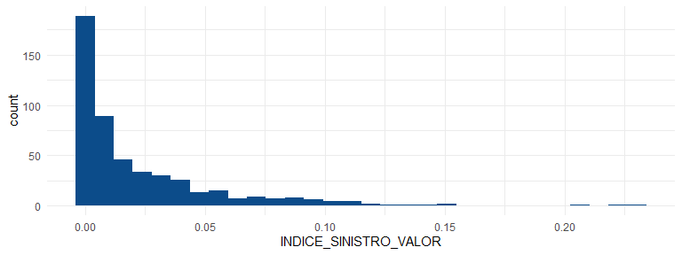

|  | INDICE_ SINISTRO_ VALOR |
| --- | --- |
| **Média** | 0.02 |
| **Desv.padrão** | 0.03 |
| **Mín** | 0.00 |
| **Q1** | 0.00 |
| **Med** | 0.01 |
| **Q3** | 0.03 |
| **Máx** | 0.23 |
| **MDA** | 0.01 |
| **IQE** | 0.03 |

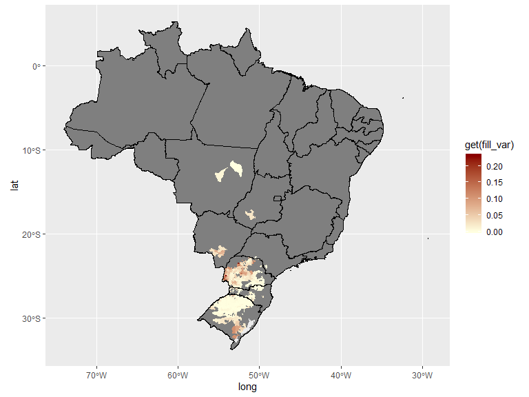

## Proagro

### Valor Enquadrado Médio

O valor enquadrado médio é mais alto no Proagro Tradicional do que no Proagro Mais, porém quando olhamos o valor enquadrado/área o valor do PRONAF é bem maior.

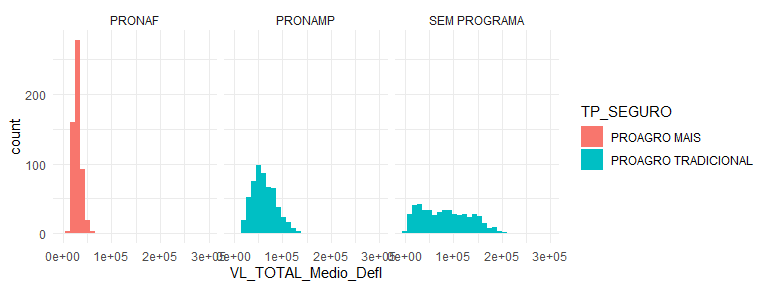

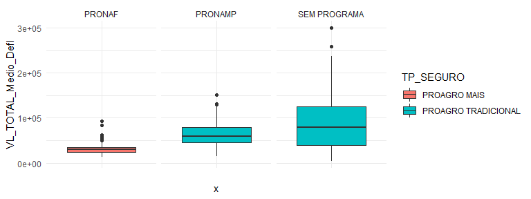

### Estatística descritiva

**VL_TOTAL_Medio_Defl por PROGRAMA**  
**Data Frame:** Proagro_soja_mun  
**N:** 555

|  | PRONAF | PRONAMP | SEM PROGRAMA |
| --- | --- | --- | --- |
| **Média** | 30470.55 | 62776.38 | 84554.79 |
| **Desv.padrão** | 8505.38 | 24354.97 | 52169.06 |
| **Mín** | 13932.58 | 15290.83 | 3568.20 |
| **Q1** | 24656.20 | 44983.81 | 39693.13 |
| **Med** | 29502.63 | 59336.91 | 79006.80 |
| **Q3** | 34686.97 | 79016.00 | 125397.58 |
| **Máx** | 92829.08 | 151314.92 | 300000.00 |
| **MDA** | 7390.41 | 25086.01 | 63163.57 |
| **IQE** | 9967.27 | 33998.55 | 85428.31 |

### Valor Enquadrado por Área

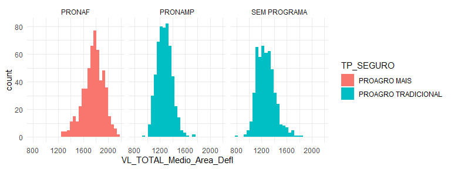

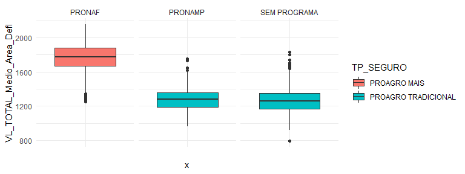

### Estatística descritiva  
**VL_TOTAL_Medio_Area_Defl por PROGRAMA**  
**Data Frame:** Proagro_soja_mun  
**N:** 555

|  | PRONAF | PRONAMP | SEM PROGRAMA |
| --- | --- | --- | --- |
| **Média** | 1762.77 | 1277.22 | 1269.23 |
| **Desv.padrão** | 166.57 | 118.73 | 144.09 |
| **Mín** | 1254.51 | 962.91 | 790.06 |
| **Q1** | 1666.36 | 1189.33 | 1164.48 |
| **Med** | 1772.45 | 1276.36 | 1255.23 |
| **Q3** | 1881.25 | 1355.09 | 1351.89 |
| **Máx** | 2154.40 | 1749.66 | 1833.21 |
| **MDA** | 159.16 | 127.18 | 138.86 |
| **IQE** | 213.41 | 165.00 | 186.82 |

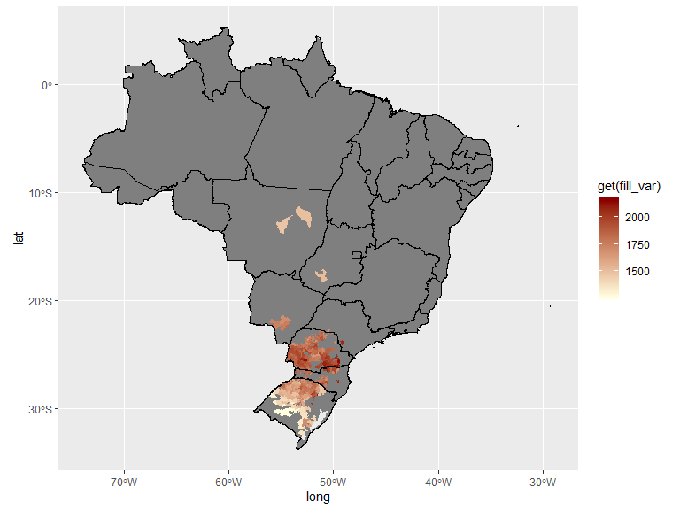

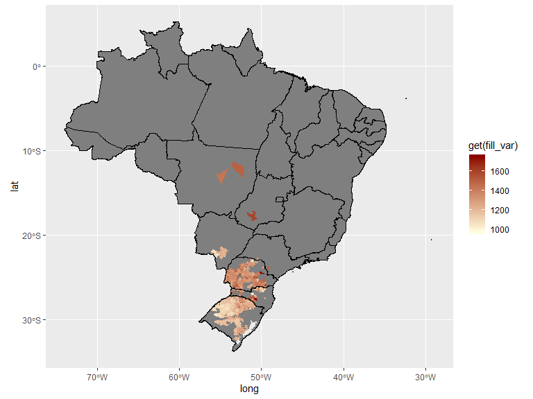

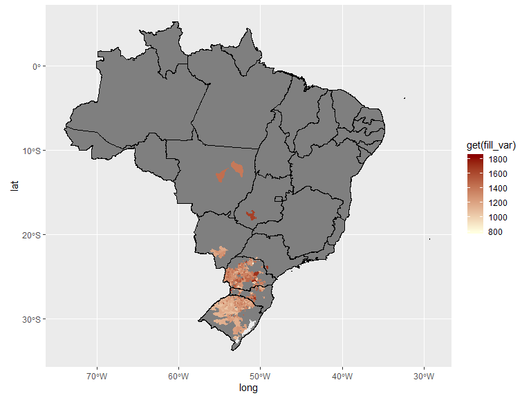

### Prêmio Médio

O Prêmio médio do Proagro Mais é bem concentrado e bem abaixo do Proagro Tradicional, porém o Prêmio/Área é bem parecido.

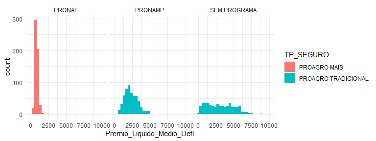

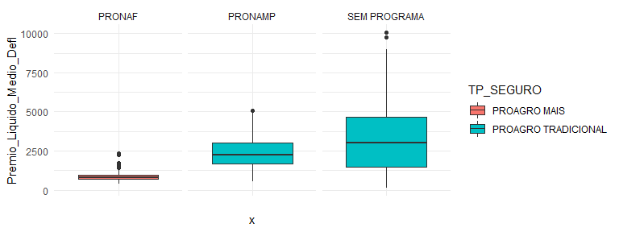

### Estatística descritiva

**Premio_Liquido_Medio_Defl por PROGRAMA**  
**Data Frame:** Proagro_soja_mun  
**N:** 555

|  | PRONAF | PRONAMP | SEM PROGRAMA |
| --- | --- | --- | --- |
| **Média** | 844.32 | 2363.47 | 3177.75 |
| **Desv.padrão** | 237.93 | 916.00 | 1948.91 |
| **Mín** | 401.41 | 567.83 | 119.66 |
| **Q1** | 676.87 | 1681.66 | 1465.93 |
| **Med** | 817.00 | 2225.57 | 3021.52 |
| **Q3** | 963.32 | 3012.69 | 4670.79 |
| **Máx** | 2364.19 | 5070.75 | 10060.94 |
| **MDA** | 212.69 | 942.59 | 2342.97 |
| **IQE** | 286.06 | 1329.61 | 3173.41 |

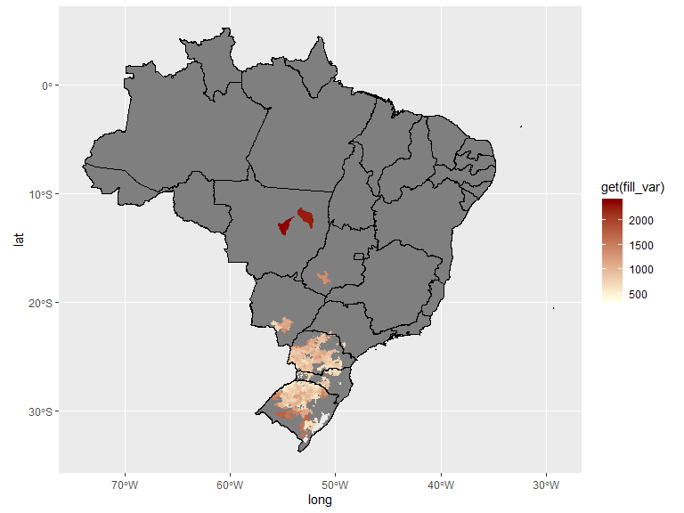

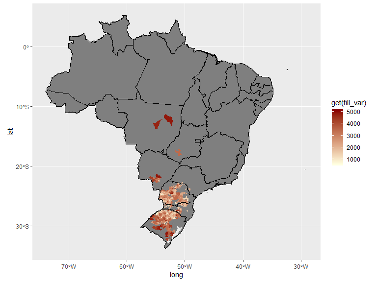

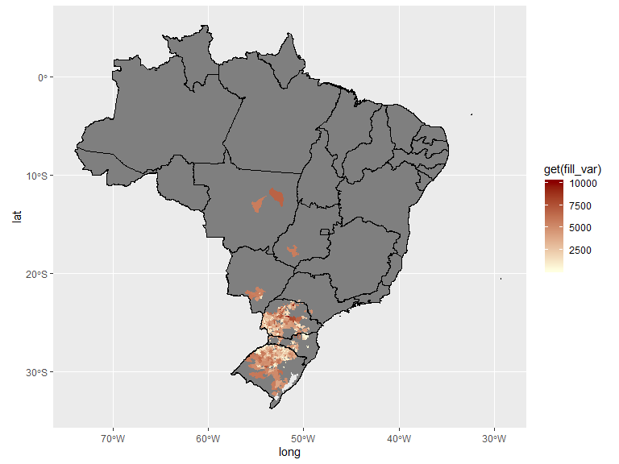

### Prêmio Médio por Área

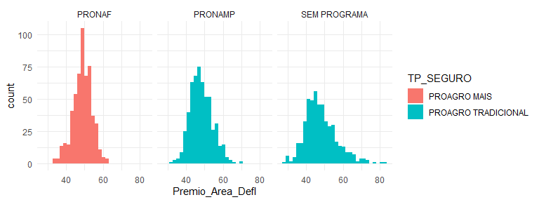

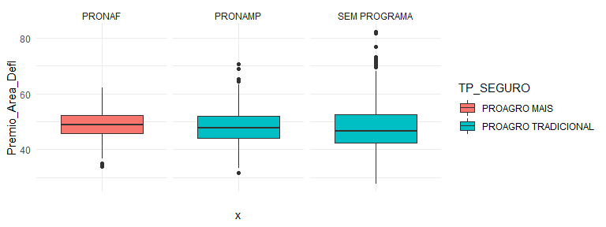

### Estatística descritiva

**Premio_Area_Defl por PROGRAMA**  
**Data Frame:** Proagro_soja_mun  
**N:** 555

|  | PRONAF | PRONAMP | SEM PROGRAMA |
| --- | --- | --- | --- |
| **Média** | 48.82 | 48.24 | 48.12 |
| **Desv.padrão** | 5.05 | 5.92 | 8.59 |
| **Mín** | 33.98 | 31.57 | 27.62 |
| **Q1** | 45.78 | 44.00 | 42.28 |
| **Med** | 48.99 | 47.65 | 46.62 |
| **Q3** | 52.35 | 52.06 | 52.70 |
| **Máx** | 62.15 | 70.53 | 82.19 |
| **MDA** | 4.96 | 5.98 | 7.72 |
| **IQE** | 6.57 | 8.04 | 10.40 |

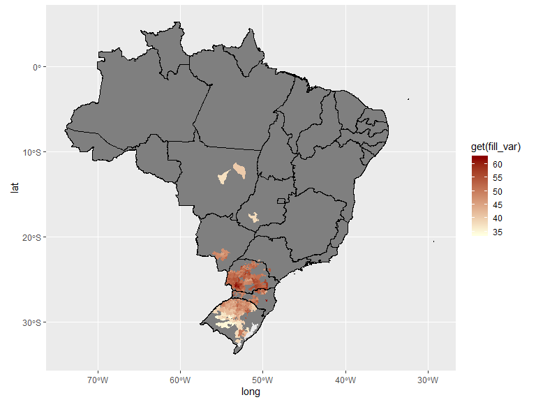

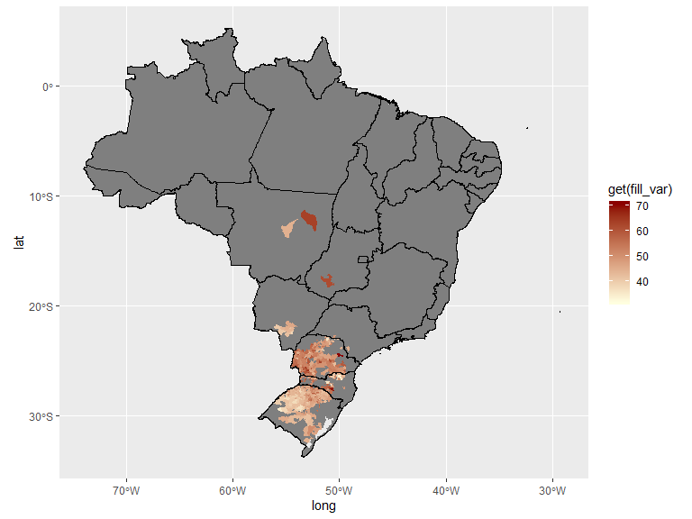

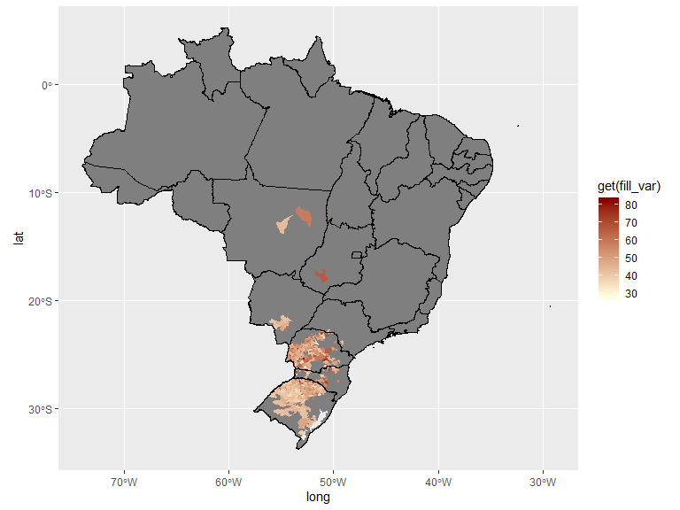

### Índice de Incidência Global (Qtd Sinistros/Qtd Total)

Apesar do número de municípios com sinistros do Proagro MAis ter sido bem superior aos demais, os Índices de Incidência são bem parecidos, uma vez que o % de seguros com sinistros são bem próximos.

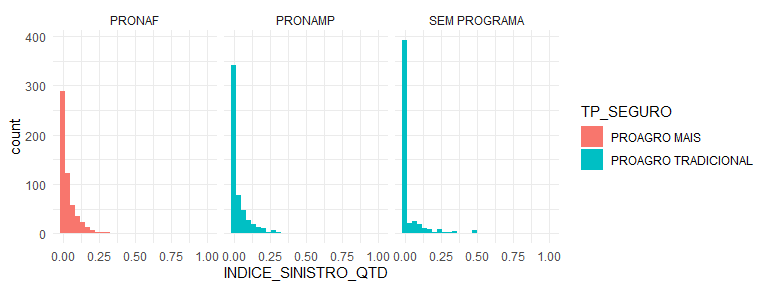

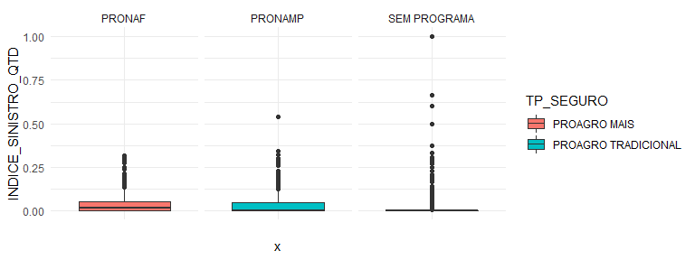

### Estatística descritiva

**INDICE_SINISTRO_QTD por PROGRAMA**  
**Data Frame:** Proagro_soja_mun  
**N:** 555

|  | PRONAF | PRONAMP | SEM PROGRAMA |
| --- | --- | --- | --- |
| **Média** | 0.04 | 0.04 | 0.04 |
| **Desv.padrão** | 0.05 | 0.07 | 0.10 |
| **Mín** | 0.00 | 0.00 | 0.00 |
| **Q1** | 0.00 | 0.00 | 0.00 |
| **Med** | 0.02 | 0.00 | 0.00 |
| **Q3** | 0.05 | 0.05 | 0.00 |
| **Máx** | 0.32 | 0.54 | 1.00 |
| **MDA** | 0.02 | 0.00 | 0.00 |
| **IQE** | 0.05 | 0.05 | 0.00 |

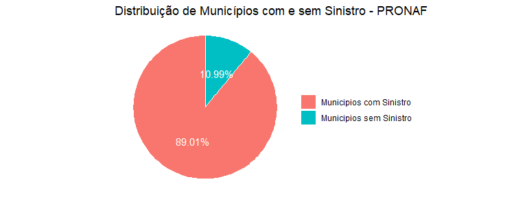

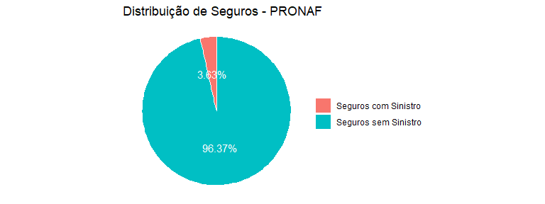

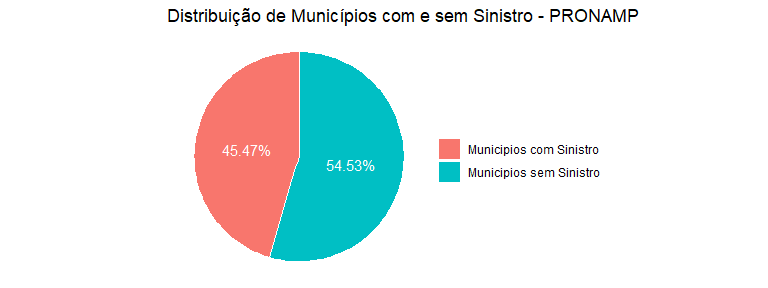

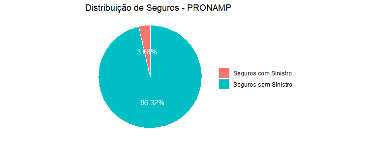

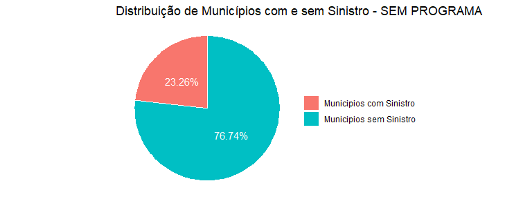

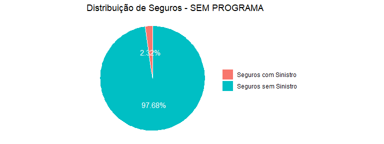

Retirando os zeros.

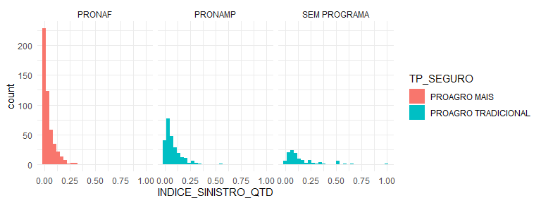

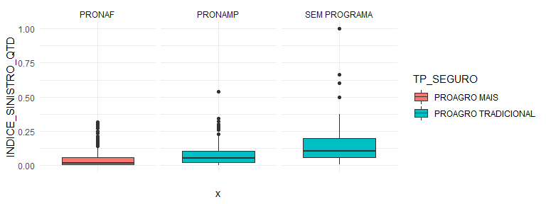

### Estatística descritiva  
**INDICE_SINISTRO_QTD por PROGRAMA**  
**Data Frame:** Proagro_soja_mun  
**N:** 494

|  | PRONAF | PRONAMP | SEM PROGRAMA |
| --- | --- | --- | --- |
| **Média** | 0.04 | 0.08 | 0.15 |
| **Desv.padrão** | 0.06 | 0.08 | 0.16 |
| **Mín** | 0.00 | 0.00 | 0.01 |
| **Q1** | 0.01 | 0.02 | 0.06 |
| **Med** | 0.02 | 0.05 | 0.10 |
| **Q3** | 0.06 | 0.11 | 0.20 |
| **Máx** | 0.32 | 0.54 | 1.00 |
| **MDA** | 0.03 | 0.05 | 0.09 |
| **IQE** | 0.05 | 0.08 | 0.14 |

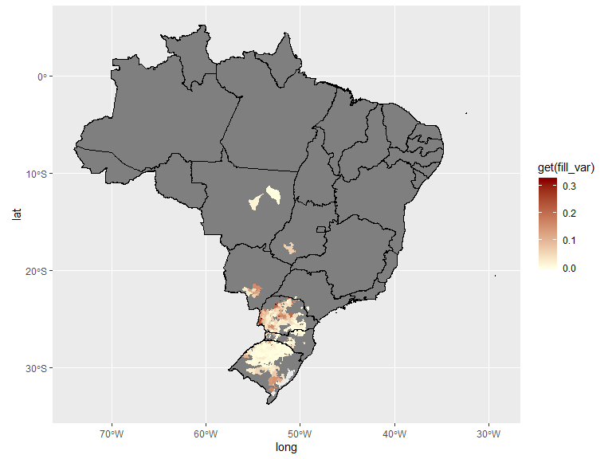

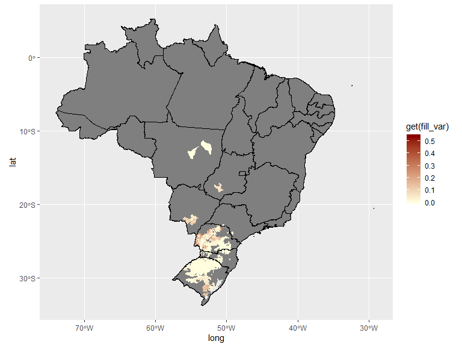

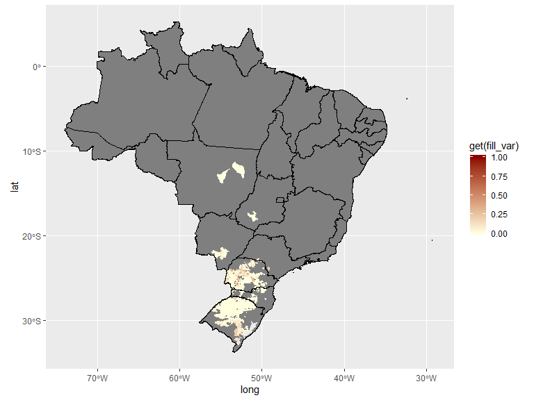

### Sinistro Médio

O sinistro médio do Proagro Mais é menor, porém não temos como comparar sem saber a área afetada. O ideal seria que tivéssemos a área que sofreu sinistro de cada município para compararmos Sinistro/Área.

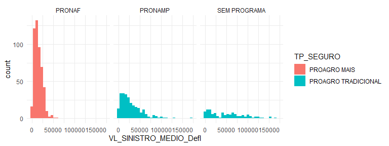

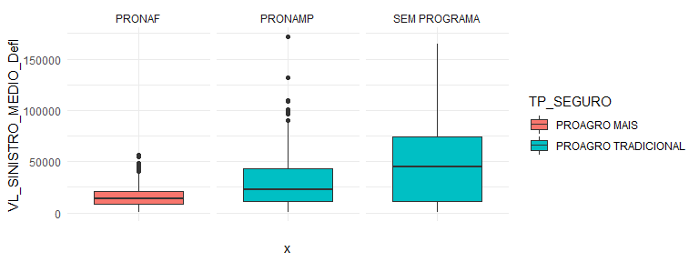

### Estatística descritiva  
**VL_SINISTRO_MEDIO_Defl por PROGRAMA**  
**Data Frame:** Proagro_soja_mun  
**N:** 555

|  | PRONAF | PRONAMP | SEM PROGRAMA |
| --- | --- | --- | --- |
| **Média** | 15295.30 | 29848.80 | 50107.58 |
| **Desv.padrão** | 9132.94 | 25420.64 | 40643.21 |
| **Mín** | 774.66 | 253.53 | 557.72 |
| **Q1** | 8447.62 | 10942.09 | 11552.25 |
| **Med** | 13536.95 | 22984.79 | 44894.31 |
| **Q3** | 20949.75 | 42854.37 | 74175.96 |
| **Máx** | 56383.66 | 171643.26 | 164682.79 |
| **MDA** | 8798.79 | 20702.94 | 46829.64 |
| **IQE** | 12490.29 | 31806.52 | 62623.72 |

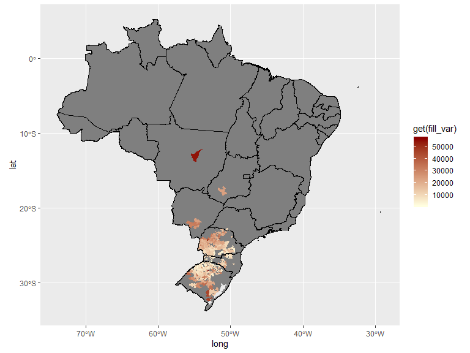

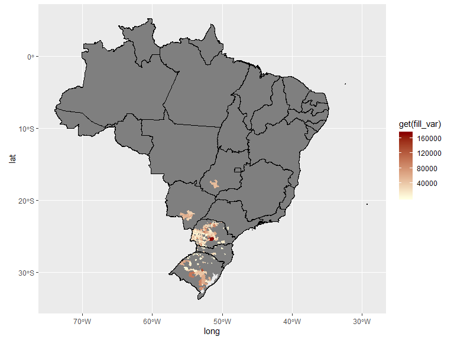

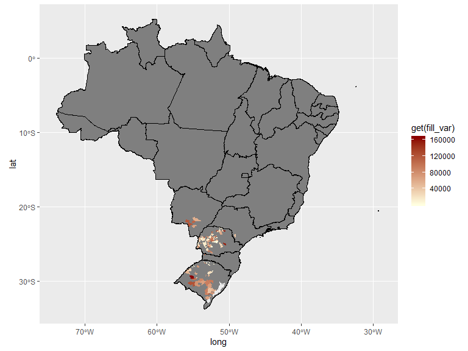

### Índice de Sinistralidade

O índice de sinistralidade dos prorgamas possuem médias parecidas, porém temos um comportamento interessante. O Proagro Tradicional possui uma quantidade maior de índices zerados, porém, quando os valores ocorrem, tendem a ser maiores que o Proagro Mais.

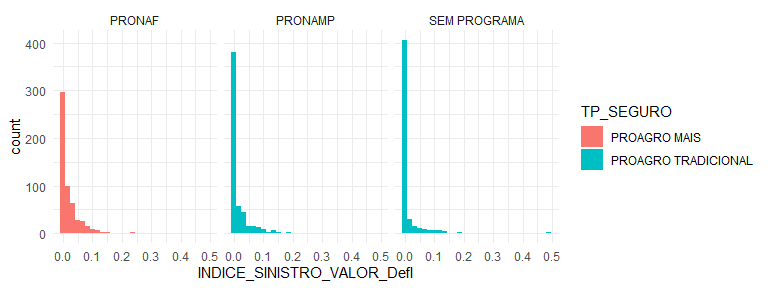

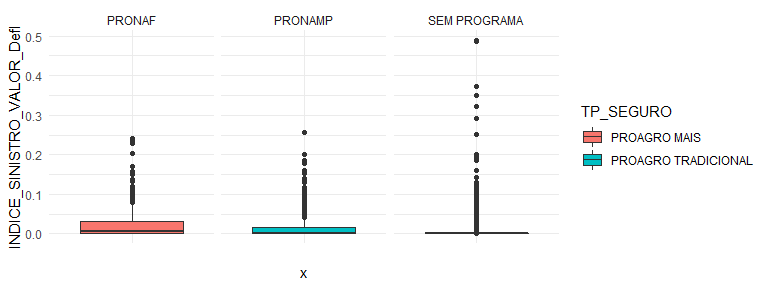

### Estatística descritiva  
**INDICE_SINISTRO_VALOR_Defl por PROGRAMA**  
**Data Frame:** Proagro_soja_mun  
**N:** 555

|  | PRONAF | PRONAMP | SEM PROGRAMA |
| --- | --- | --- | --- |
| **Média** | 0.02 | 0.02 | 0.02 |
| **Desv.padrão** | 0.03 | 0.03 | 0.05 |
| **Mín** | 0.00 | 0.00 | 0.00 |
| **Med** | 0.01 | 0.00 | 0.00 |
| **Máx** | 0.24 | 0.26 | 0.49 |

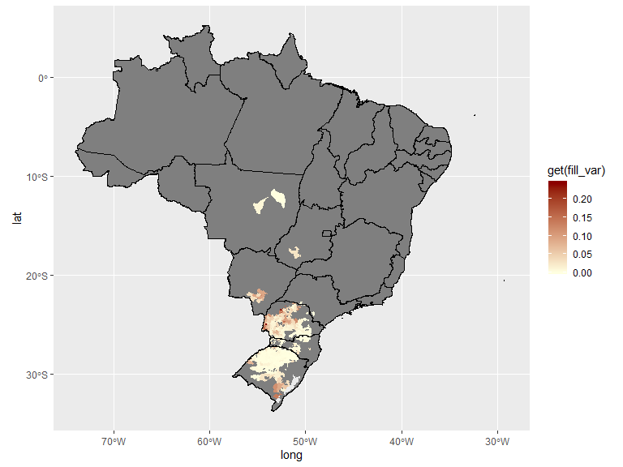

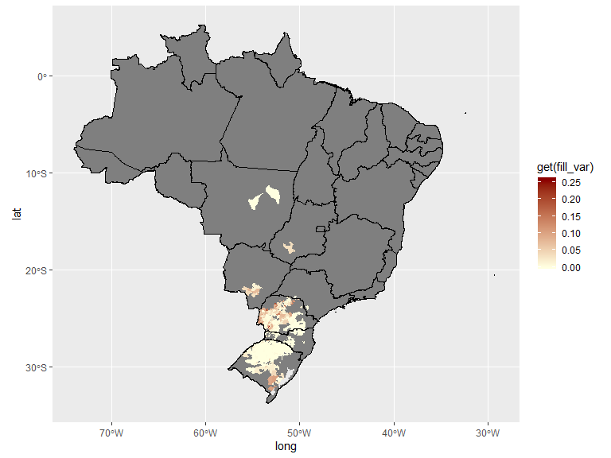

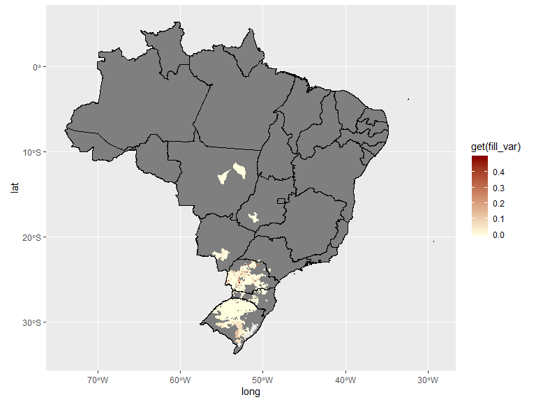

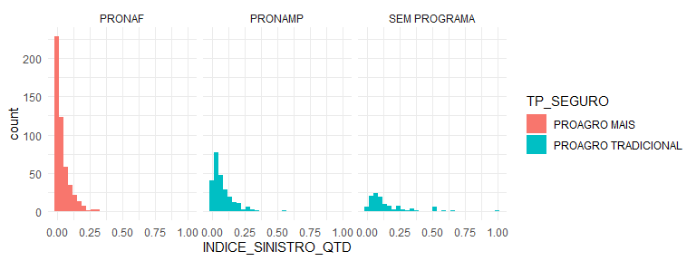

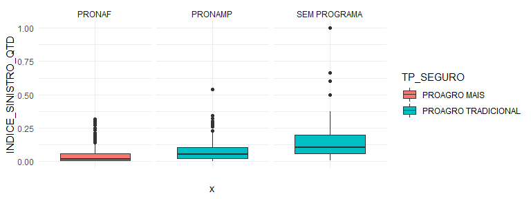

|  | PRONAF | PRONAMP | SEM PROGRAMA |
| --- | --- | --- | --- |
| **Média** | 0.04 | 0.08 | 0.15 |
| **Desv.padrão** | 0.06 | 0.08 | 0.16 |
| **Mín** | 0.00 | 0.00 | 0.01 |
| **Med** | 0.02 | 0.05 | 0.10 |
| **Máx** | 0.32 | 0.54 | 1.00 |